# Análisis de la Industria Manufacturera Colombiana

Reporte Estadístico

2026-04-20

# 1 Resumen Ejecutivo

Este documento presenta un análisis integral de la evolución de la industria manufacturera en Colombia, abarcando aspectos de establecimientos, producción, empleo y productividad a nivel nacional y regional.

# 2 Análisis Nacional

## 2.1 Cantidad de Establecimientos Únicos

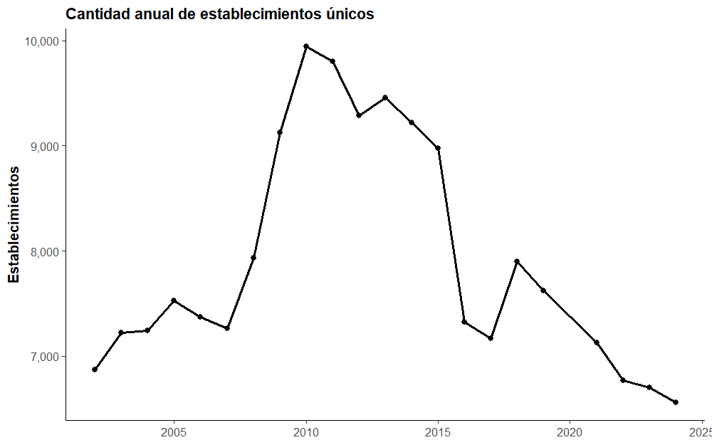

Evolución temporal de establecimientos únicos

La cantidad de establecimientos únicos muestra una tendencia creciente hasta 2010, alcanzando un pico cercano a los 10,000 establecimientos. Posteriormente se observa un descenso sostenido, reflejando posibles procesos de consolidación industrial y desafíos económicos del sector manufacturero.

## 2.2 Evolución por Sector Económico

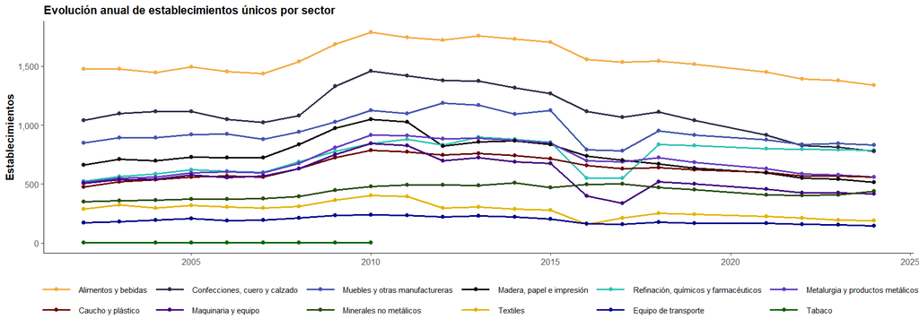

Evolución anual de establecimientos únicos por sector

El sector de alimentos y bebidas lidera consistentemente en número de establecimientos, seguido por confecciones y muebles. Se evidencia una diversificación sectorial estable a lo largo del período analizado, con reducción generalizada post-2015 en la mayoría de sectores.

## 2.3 Participación Sectorial

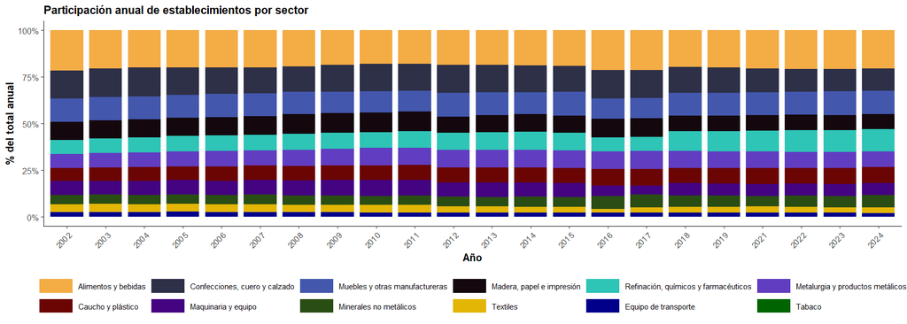

Participación anual de establecimientos por sector

La estructura porcentual del sector manufacturero se mantiene relativamente estable en el tiempo. Alimentos y bebidas representa aproximadamente el 20% del total, confecciones alrededor del 15%, evidenciando una composición industrial consistente y diversificada.

## 2.4 Valor Agregado por Sector

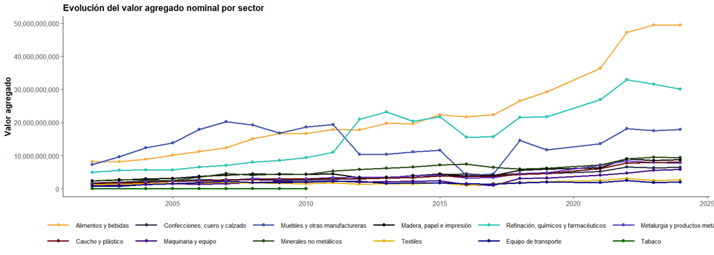

Evolución del valor agregado nominal por sector

El valor agregado muestra un crecimiento significativo post-2020, especialmente en alimentos y bebidas, que alcanza los 50 mil millones. Refinación y químicos también experimenta un crecimiento notable, reflejando la importancia estratégica de estos sectores en la economía nacional.

## 2.5 Personal Ocupado por Sector

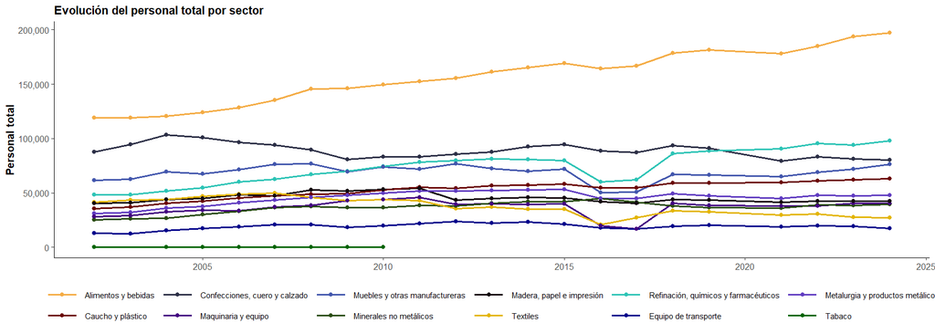

Evolución del personal total por sector

Alimentos y bebidas es el principal empleador del sector manufacturero, con cerca de 200,000 trabajadores en 2024. Confecciones y refinación química también representan fuentes importantes de empleo, aunque con tendencias variables según ciclos económicos.

## 2.6 Productividad Laboral por Sector

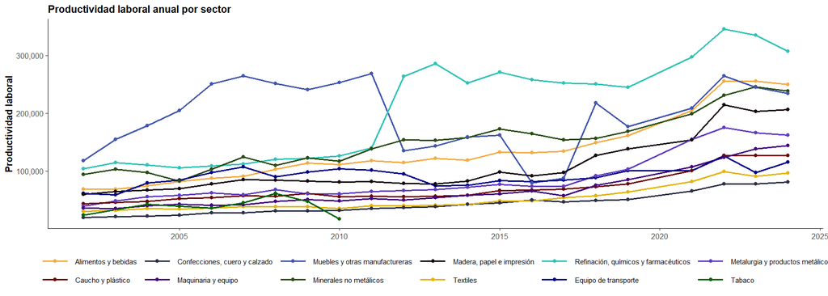

Productividad laboral anual por sector

La productividad laboral muestra alta heterogeneidad entre sectores. Refinación química presenta los niveles más altos, superando 300,000 unidades en años recientes. Esta disparidad refleja diferentes niveles de intensidad de capital y tecnología entre industrias.

# 3 Análisis Regional

## 3.1 Establecimientos por Región

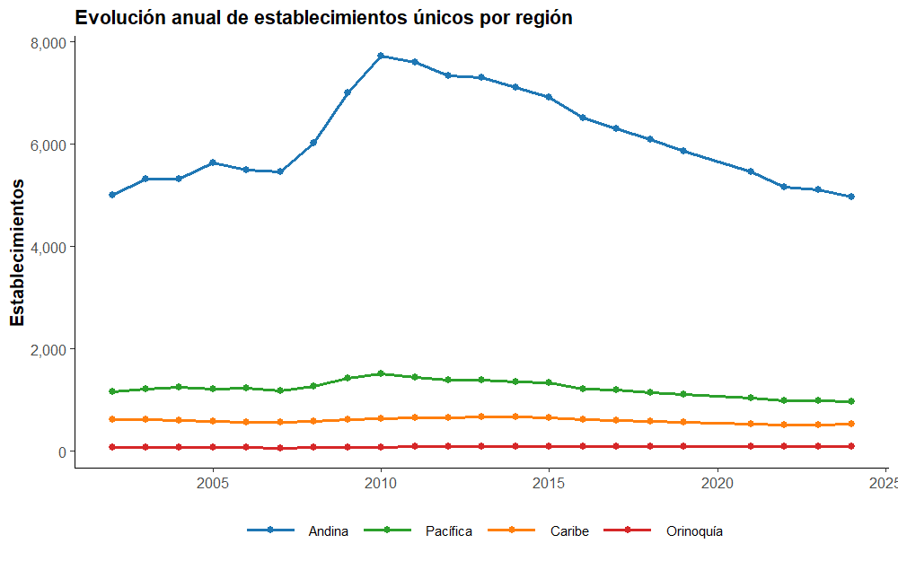

Evolución anual de establecimientos únicos por región

La región Andina concentra la mayor cantidad de establecimientos, alcanzando cerca de 8,000 en su punto máximo. Las regiones Pacífica, Caribe y Orinoquía mantienen participaciones significativamente menores, evidenciando la alta concentración geográfica de la actividad manufacturera.

## 3.2 Participación Regional

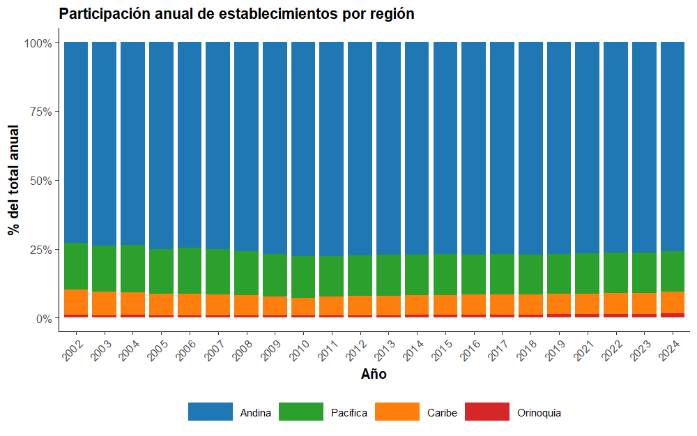

Participación anual de establecimientos por región

La región Andina representa consistentemente más del 70% de los establecimientos manufactureros del país. La Pacífica mantiene alrededor del 15%, mientras Caribe y Orinoquía participan con porcentajes menores, mostrando una estructura regional estable.

## 3.3 Valor Agregado Regional

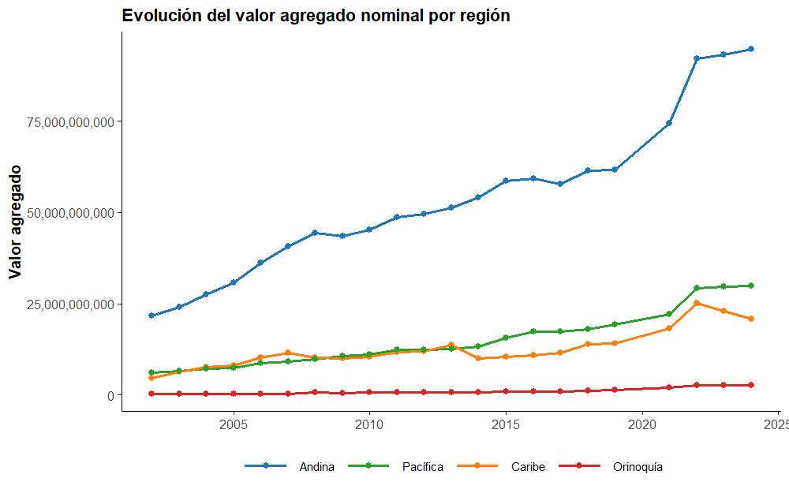

Evolución del valor agregado nominal por región

El valor agregado de la región Andina experimenta un crecimiento exponencial post-2020, superando los 90 mil millones. Las regiones Pacífica y Caribe muestran crecimientos más moderados, consolidando la brecha de desarrollo industrial entre regiones.

## 3.4 Personal Ocupado Regional

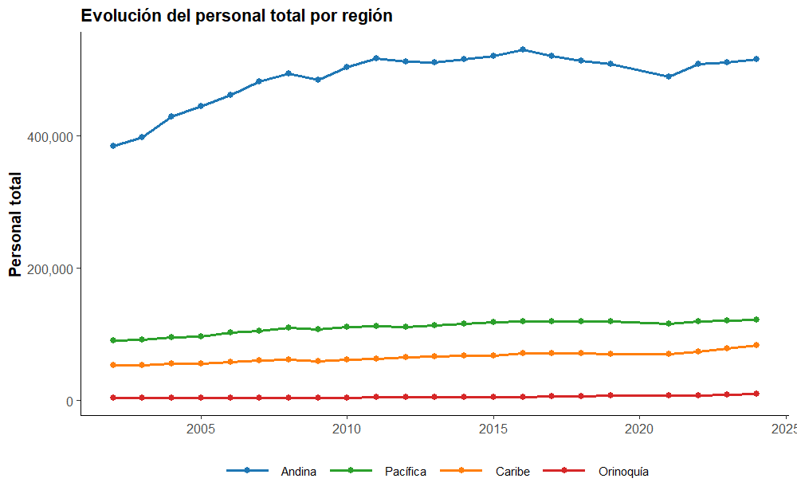

Evolución del personal total por región

## 3.5 Productividad Laboral Regional

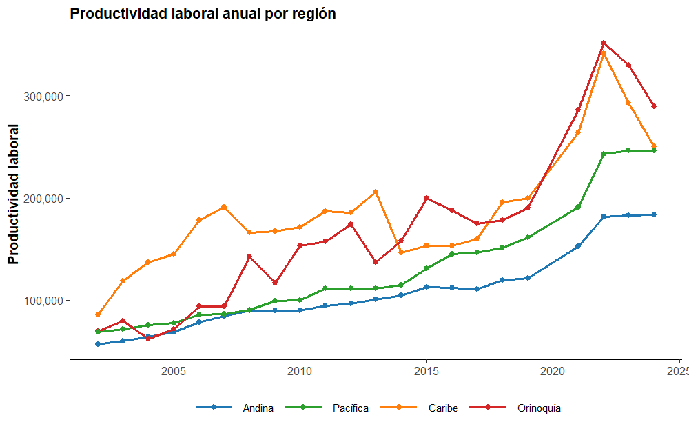

Productividad laboral anual por región

# 4 Análisis Cruzado: Región-Sector

## 4.1 Establecimientos por Región y Sector

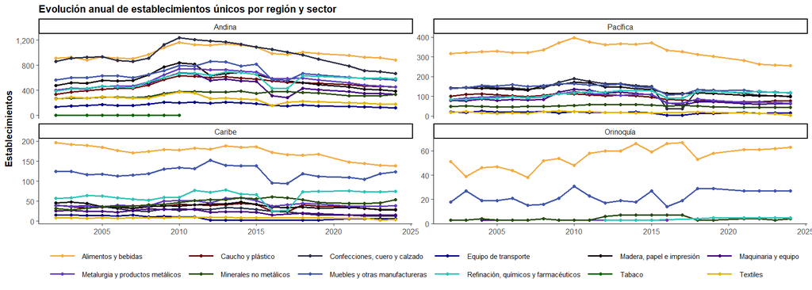

Evolución anual de establecimientos únicos por región y sector

En la Andina predominan confecciones y alimentos, mientras en Pacífica destaca alimentos. Cada región muestra especialización sectorial particular, con la Andina presentando mayor diversificación industrial comparada con las demás regiones.